# Question

A turtle starts at the star in the middle, facing North. She walks forward for a while, then turns 60° either to her right (clockwise) or to her left (counterclockwise). She repeats this, marking her path with various colors, until she has drawn 6 segments.

The distance between adjacent dots is 1 unit.

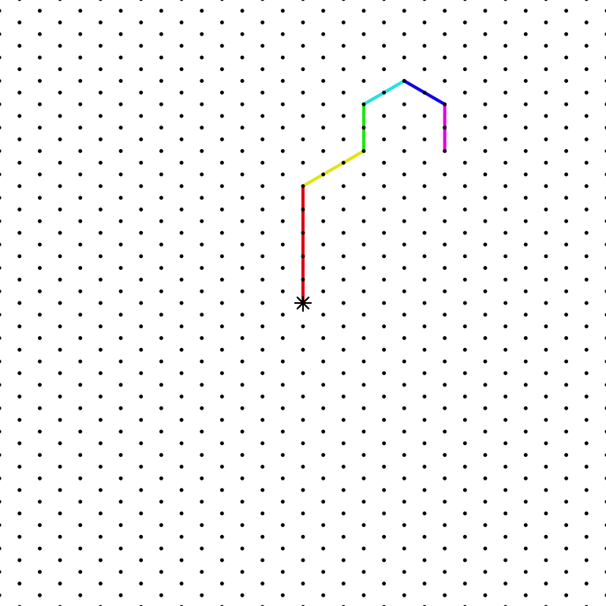

Describe the path taken by the turtle.

## Answerlist

- 1
- 2
- 3
- 4
- 5
- right
- left
- 1
- 2
- 3
- 4
- 5
- right
- left
- 1
- 2
- 3
- 4
- 5
- right
- left
- 1
- 2
- 3
- 4
- 5
- right
- left
- 1
- 2
- 3
- 4
- 5
- right
- left
- 1
- 2
- 3
- 4
- 5

# Solution

- Go 5
- Turn right
- Go 3
- Turn left
- Go 2
- Turn right
- Go 2
- Turn right
- Go 2
- Turn right
- Go 2

# Meta-information

extype: cloze exclozetype: schoice|schoice|schoice|schoice|schoice|schoice|schoice|schoice|schoice|schoice|schoice exsolution: 00001|10|00100|01|01000|10|01000|10|01000|10|01000 exname: turtle_path_C